# Comparaison parametres pour differents regimes alimentaires

Serigne Fallou MBacke NGOM

2024-02-16

## Importation et reoganisation des data

```r
data = read.csv2("Données  NIANG fin Janvier 2024.csv", dec = ".", check.names = FALSE)
data = data.frame(data, check.names=FALSE)
print(data)
```

```
##    Regimes  pmi  PMF GPMA   GPMR  TCS  TCA  TS
## 1  Regime1 2.55 4.32 1.77  69.24 1.25 4.26  90
## 2  Regime1 2.56 4.03 1.48  57.78 1.09 4.56  70
## 3  Regime1 2.53 5.44 2.91 114.95 1.82 2.48  60
## 4  Regime2 2.53 3.96 1.43  56.70 1.07 4.92  90
## 5  Regime2 2.56 4.19 1.63  63.59 1.17 4.72 100
## 6  Regime2 2.55 5.30 2.75 107.93 1.74 3.08  90
## 7  Regime3 2.55 3.63 1.08  42.31 0.84 6.33  90
## 8  Regime3 2.56 5.79 3.24 126.64 1.95 2.32  70
## 9  Regime3 2.53 4.94 2.41  95.26 1.59 2.91  60
## 10 Regime4 2.53 4.41 1.88  74.18 1.32 3.99  90
## 11 Regime4 2.56 5.44 2.88 112.54 1.80 2.76  90
## 12 Regime4 2.55 5.79 3.24 127.06 1.95 2.64  90
```

## Visualisation des donnees

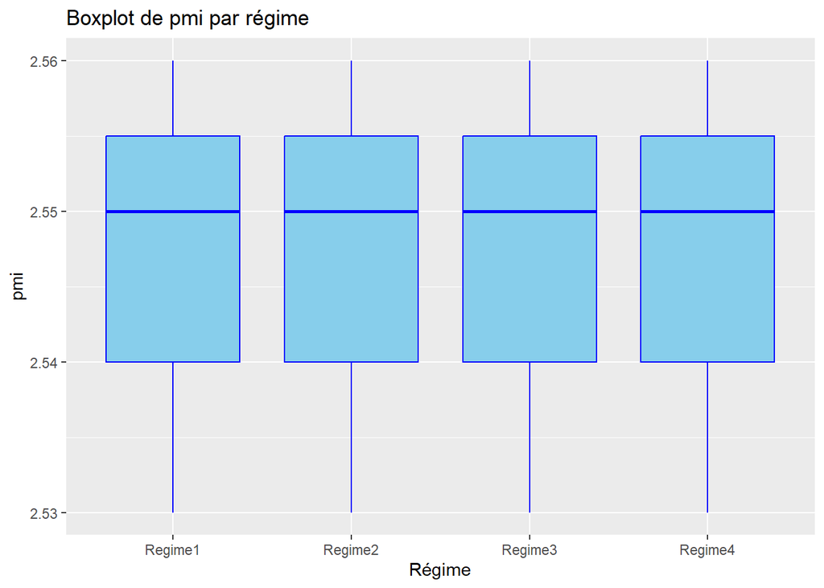

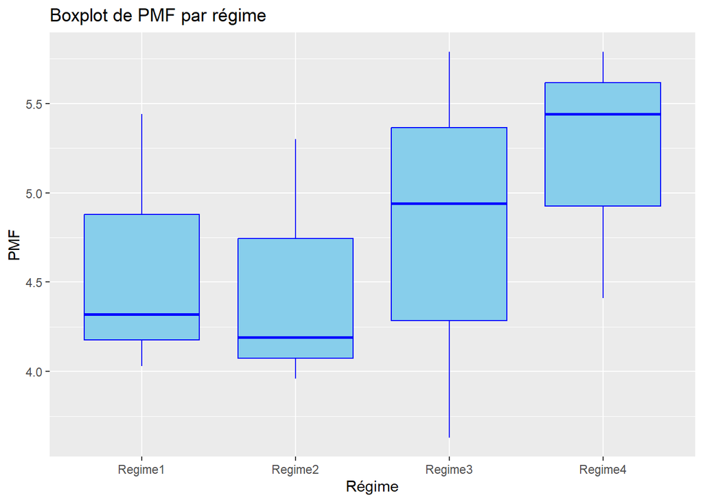

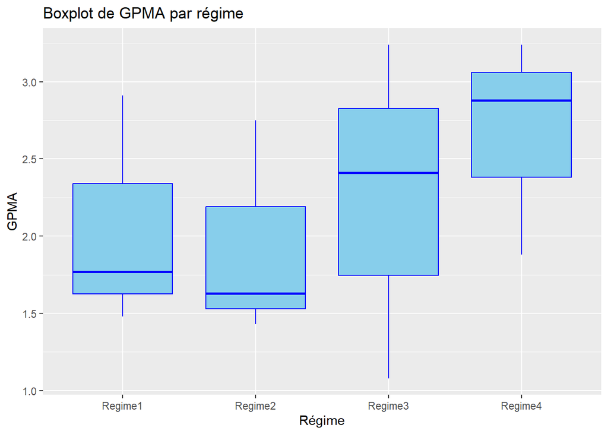

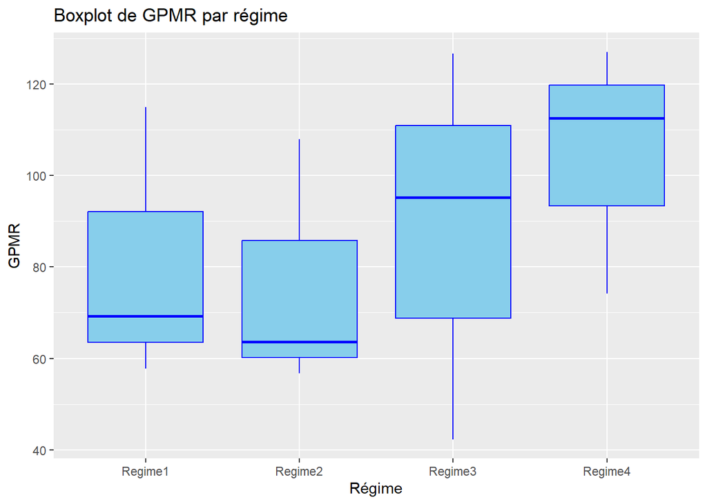

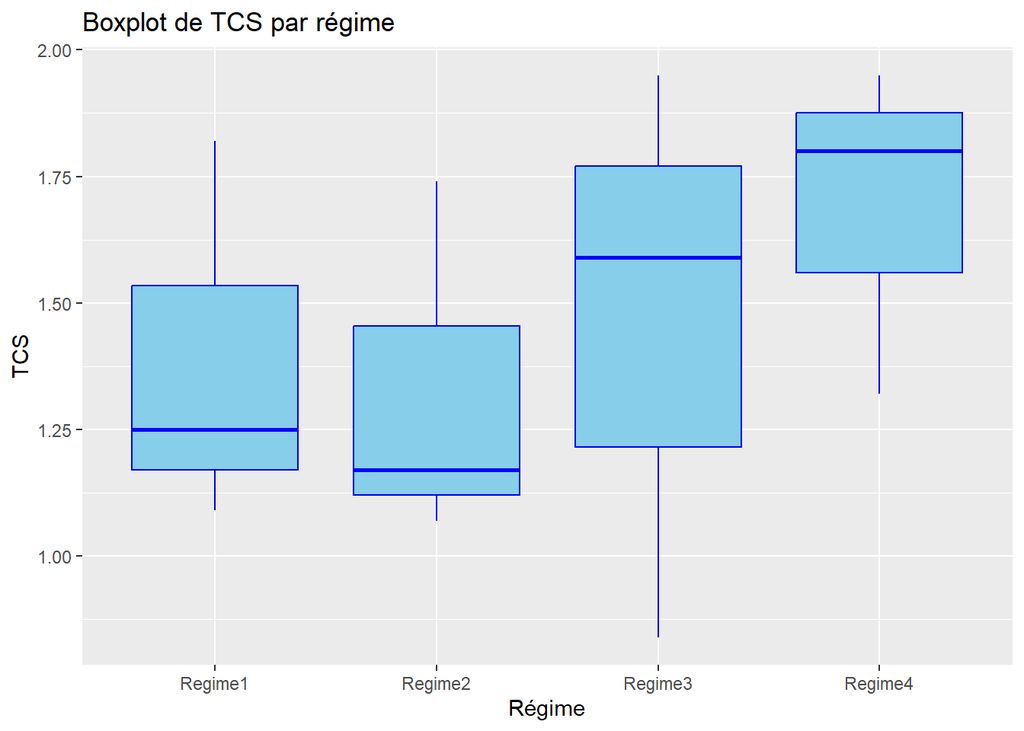

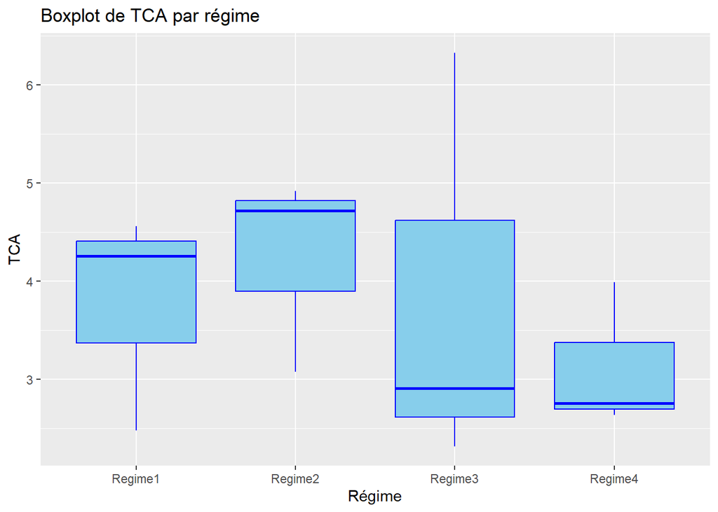

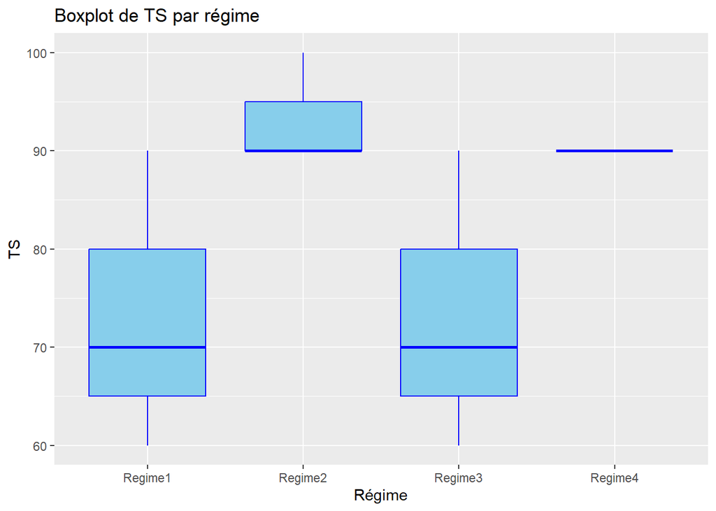

```r
library(ggplot2)

plots <- list()
for (col in names(data)[-1]) {
  # Créer le boxplot pour la variable actuelle
  plot <- ggplot(data, aes_string(x = 'Regimes', y = col)) +
    geom_boxplot(fill = "skyblue", color = "blue") +
    labs(title = paste("Boxplot de", col, "par régime"), x = "Régime", y = col)

  plots[[col]] <- plot
}
plots
```

## Analyses statistiques:

### Statistiques globales pour les parametres

- **RESUME GLOBAL (moyenne, median, max, quartiles, …) DES PARAMETRES**

```r
data$Regimes = factor(data$Regimes)
summary(data)
```

```
##     Regimes       pmi             PMF             GPMA            GPMR
##  Regime1:3   Min.   :2.530   Min.   :3.630   Min.   :1.080   Min.   : 42.31
##  Regime2:3   1st Qu.:2.530   1st Qu.:4.150   1st Qu.:1.593   1st Qu.: 62.14
##  Regime3:3   Median :2.550   Median :4.675   Median :2.145   Median : 84.72
##  Regime4:3   Mean   :2.547   Mean   :4.770   Mean   :2.225   Mean   : 87.35
##              3rd Qu.:2.560   3rd Qu.:5.440   3rd Qu.:2.888   3rd Qu.:113.14
##              Max.   :2.560   Max.   :5.790   Max.   :3.240   Max.   :127.06
##       TCS             TCA              TS
##  Min.   :0.840   Min.   :2.320   Min.   : 60.0
##  1st Qu.:1.150   1st Qu.:2.730   1st Qu.: 70.0
##  Median :1.455   Median :3.535   Median : 90.0
##  Mean   :1.466   Mean   :3.748   Mean   : 82.5
##  3rd Qu.:1.805   3rd Qu.:4.600   3rd Qu.: 90.0
##  Max.   :1.950   Max.   :6.330   Max.   :100.0
```

- **CALCLCUL ECART-TYPES GLOBAUX DES PARAMETRES**

```r
apply(data[, -1], 2, sd)
```

```
##         pmi         PMF        GPMA        GPMR         TCS         TCA
##  0.01302678  0.76634908  0.76554793 30.01720168  0.38629848  1.24186169
##          TS
## 13.56801051
```

### Statistiques parametres pour le REGIME 1:

- **RESUME PARAMETRES (moyenne, median, max, quartiles, …) POUR REGIME 1**

```r
summary(data[1:3,])
```

```
##     Regimes       pmi             PMF             GPMA            GPMR
##  Regime1:3   Min.   :2.530   Min.   :4.030   Min.   :1.480   Min.   : 57.78
##  Regime2:0   1st Qu.:2.540   1st Qu.:4.175   1st Qu.:1.625   1st Qu.: 63.51
##  Regime3:0   Median :2.550   Median :4.320   Median :1.770   Median : 69.24
##  Regime4:0   Mean   :2.547   Mean   :4.597   Mean   :2.053   Mean   : 80.66
##              3rd Qu.:2.555   3rd Qu.:4.880   3rd Qu.:2.340   3rd Qu.: 92.09
##              Max.   :2.560   Max.   :5.440   Max.   :2.910   Max.   :114.95
##       TCS             TCA              TS
##  Min.   :1.090   Min.   :2.480   Min.   :60.00
##  1st Qu.:1.170   1st Qu.:3.370   1st Qu.:65.00
##  Median :1.250   Median :4.260   Median :70.00
##  Mean   :1.387   Mean   :3.767   Mean   :73.33
##  3rd Qu.:1.535   3rd Qu.:4.410   3rd Qu.:80.00
##  Max.   :1.820   Max.   :4.560   Max.   :90.00
```

- **CALCLCUL ECART-TYPES DES PARAMETRES POUR REGIME 1**

```r
apply(data[1:3, -1], 2, sd)
```

```
##         pmi         PMF        GPMA        GPMR         TCS         TCA
##  0.01527525  0.74460280  0.75593210 30.24661028  0.38370996  1.12433684
##          TS
## 15.27525232
```

### Statistiques parametres pour le REGIME 2:

- **RESUME PARAMETRES (moyenne, median, max, quartiles, …) POUR REGIME 2**

```r
summary(data[4:6,])
```

```
##     Regimes       pmi             PMF             GPMA            GPMR
##  Regime1:0   Min.   :2.530   Min.   :3.960   Min.   :1.430   Min.   : 56.70
##  Regime2:3   1st Qu.:2.540   1st Qu.:4.075   1st Qu.:1.530   1st Qu.: 60.15
##  Regime3:0   Median :2.550   Median :4.190   Median :1.630   Median : 63.59
##  Regime4:0   Mean   :2.547   Mean   :4.483   Mean   :1.937   Mean   : 76.07
##              3rd Qu.:2.555   3rd Qu.:4.745   3rd Qu.:2.190   3rd Qu.: 85.76
##              Max.   :2.560   Max.   :5.300   Max.   :2.750   Max.   :107.93
##       TCS             TCA             TS
##  Min.   :1.070   Min.   :3.08   Min.   : 90.00
##  1st Qu.:1.120   1st Qu.:3.90   1st Qu.: 90.00
##  Median :1.170   Median :4.72   Median : 90.00
##  Mean   :1.327   Mean   :4.24   Mean   : 93.33
##  3rd Qu.:1.455   3rd Qu.:4.82   3rd Qu.: 95.00
##  Max.   :1.740   Max.   :4.92   Max.   :100.00
```

- **CALCLCUL ECART-TYPES DES PARAMETRES POUR REGIME 2**

```r
apply(data[4:6, -1], 2, sd)
```

```
##         pmi         PMF        GPMA        GPMR         TCS         TCA
##  0.01527525  0.71654262  0.71143048 27.80293929  0.36143234  1.00955436
##          TS
##  5.77350269
```

### Statistiques parametres pour le REGIME 3:

- **RESUME PARAMETRES (moyenne, median, max, quartiles, …) POUR REGIME 3**

```r
summary(data[7:9,])
```

```
##     Regimes       pmi             PMF             GPMA            GPMR
##  Regime1:0   Min.   :2.530   Min.   :3.630   Min.   :1.080   Min.   : 42.31
##  Regime2:0   1st Qu.:2.540   1st Qu.:4.285   1st Qu.:1.745   1st Qu.: 68.78
##  Regime3:3   Median :2.550   Median :4.940   Median :2.410   Median : 95.26
##  Regime4:0   Mean   :2.547   Mean   :4.787   Mean   :2.243   Mean   : 88.07
##              3rd Qu.:2.555   3rd Qu.:5.365   3rd Qu.:2.825   3rd Qu.:110.95
##              Max.   :2.560   Max.   :5.790   Max.   :3.240   Max.   :126.64
##       TCS             TCA              TS
##  Min.   :0.840   Min.   :2.320   Min.   :60.00
##  1st Qu.:1.215   1st Qu.:2.615   1st Qu.:65.00
##  Median :1.590   Median :2.910   Median :70.00
##  Mean   :1.460   Mean   :3.853   Mean   :73.33
##  3rd Qu.:1.770   3rd Qu.:4.620   3rd Qu.:80.00
##  Max.   :1.950   Max.   :6.330   Max.   :90.00
```

- **CALCLCUL ECART-TYPES DES PARAMETRES POUR REGIME 3**

```r
apply(data[7:9, -1], 2, sd)
```

```
##         pmi         PMF        GPMA        GPMR         TCS         TCA
##  0.01527525  1.08813296  1.08960237 42.62228642  0.56630381  2.16504811
##          TS
## 15.27525232
```

### Statistiques parametres pour le REGIME 4:

- **RESUME PARAMETRES (moyenne, median, max, quartiles, …) POUR REGIME 4**

```r
summary(data[10:12,])
```

```
##     Regimes       pmi             PMF             GPMA            GPMR
##  Regime1:0   Min.   :2.530   Min.   :4.410   Min.   :1.880   Min.   : 74.18
##  Regime2:0   1st Qu.:2.540   1st Qu.:4.925   1st Qu.:2.380   1st Qu.: 93.36
##  Regime3:0   Median :2.550   Median :5.440   Median :2.880   Median :112.54
##  Regime4:3   Mean   :2.547   Mean   :5.213   Mean   :2.667   Mean   :104.59
##              3rd Qu.:2.555   3rd Qu.:5.615   3rd Qu.:3.060   3rd Qu.:119.80
##              Max.   :2.560   Max.   :5.790   Max.   :3.240   Max.   :127.06
##       TCS             TCA              TS
##  Min.   :1.320   Min.   :2.640   Min.   :90
##  1st Qu.:1.560   1st Qu.:2.700   1st Qu.:90
##  Median :1.800   Median :2.760   Median :90
##  Mean   :1.690   Mean   :3.130   Mean   :90
##  3rd Qu.:1.875   3rd Qu.:3.375   3rd Qu.:90
##  Max.   :1.950   Max.   :3.990   Max.   :90
```

- **CALCLCUL ECART-TYPES DES PARAMETRES POUR REGIME 4**

```r
apply(data[10:12, -1], 2, sd)
```

```
##         pmi         PMF        GPMA        GPMR         TCS         TCA
##  0.01527525  0.71737949  0.70465121 27.32097607  0.32908965  0.74719475
##          TS
##  0.00000000
```

## Tests statistiques: ANOVA

### PMI

```r
anova_PMI <- aov(pmi ~ Regimes, data = data)
summary(anova_PMI)
```

```
##             Df   Sum Sq   Mean Sq F value Pr(>F)
## Regimes      3 0.000000 0.0000000       0      1
## Residuals    8 0.001867 0.0002333
```

**il n’y a pas de différences significatives pour les valeurs de PMI entre les différents régimes.**

### PMF

```r
anova_PMF <- aov(PMF ~ Regimes, data = data)
summary(anova_PMF)
```

```
##             Df Sum Sq Mean Sq F value Pr(>F)
## Regimes      3  0.927  0.3090   0.447  0.726
## Residuals    8  5.533  0.6916
```

**il n’y a pas de différences significatives pour les valeurs de PMF entre les différents régimes.**

### GPMA

```r
anova_GPMA <- aov(GPMA ~ Regimes, data = data)
summary(anova_GPMA)
```

```
##             Df Sum Sq Mean Sq F value Pr(>F)
## Regimes      3  0.924  0.3080   0.446  0.727
## Residuals    8  5.523  0.6903
```

**il n’y a pas de différences significatives pour les valeurs de GPMA entre les différents régimes.**

### GPMR

```r
anova_GPMR <- aov(GPMR ~ Regimes, data = data)
summary(anova_GPMR)
```

```
##             Df Sum Sq Mean Sq F value Pr(>F)
## Regimes      3   1409   469.8   0.442  0.729
## Residuals    8   8502  1062.7
```

**il n’y a pas de différences significatives pour les valeurs de GPMR entre les différents régimes.**

### TCS

```r
anova_TCS <- aov(TCS ~ Regimes, data = data)
summary(anova_TCS)
```

```
##             Df Sum Sq Mean Sq F value Pr(>F)
## Regimes      3 0.2278 0.07592    0.43  0.737
## Residuals    8 1.4137 0.17672
```

**il n’y a pas de différences significatives pour les valeurs de TCS entre les différents régimes.**

### TCA

```r
anova_TCA <- aov(TCA ~ Regimes, data = data)
summary(anova_TCA)
```

```
##             Df Sum Sq Mean Sq F value Pr(>F)
## Regimes      3  1.906  0.6354   0.338  0.799
## Residuals    8 15.058  1.8823
```

**il n’y a pas de différences significatives pour les valeurs de TCA entre les différents régimes.**

Tansformons les donnees pour voir:

```r
data$TCA.log10 = log10(data$TCA)

anova_TCA.log10 <- aov(TCA.log10 ~ Regimes, data = data)
summary(anova_TCA.log10)
```

```
##             Df  Sum Sq  Mean Sq F value Pr(>F)
## Regimes      3 0.02593 0.008643   0.361  0.783
## Residuals    8 0.19130 0.023913
```

**Toujours, il n’y a pas de différences significatives pour les valeurs de TCA entre les différents régimes.**

### TS

```r
anova_TS <- aov(TS ~ Regimes, data = data)
summary(anova_TS)
```

```
##             Df Sum Sq Mean Sq F value Pr(>F)
## Regimes      3   1025   341.7   2.733  0.114
## Residuals    8   1000   125.0
```

**il n’y a pas de différences significatives pour les valeurs de TS entre les différents régimes.**